# Who are ASM Journals? A Gender Analysis

Ada Hagan, Begum Topcholou, Hazel Barton, Patrick Schloss

July 17, 2018

# Introduction

Scientific societies play an integral role in the formation and maintanence of scientific communities. They host conferences that provide a forum for knowledge exchange and networking, as well as opportunities for increased visibility as a researcher. Scientific societies also frequently publish the most reputable journals in their field, facilitating the peer review process to vet new research submissions. As such, societies have great power to set both professional and scientfic norms in their community by choosing what behaviors are rewarded and what types of research are accepted for publication. Given that the authorship of such research publications is a key criterium for hiring and promotion processes in academic circles, it is a coveted measure of success. Accordingly, editors and reviewers of research journals have a substantial influence over the futures of hopeful authors. While the membership of scientific societies is likely to reflective of all those who participate in the field, regardless of career track, the gatekeepers for peer review (reviewers and editors) are more reflective of the academy than the society of a whole.

Recently, scientific societies and publishers have begun examining their own data to evaluate representation of, and bias agains, women and minorities in their peer review processes. The American Geological Union found that while the acceptance rate of women-authored publications was greater than that for publications authored by men, women submitted fewer manuscripts than men and were used as reviewers only 20% of the time (Lerback, 2017). Fox et al., have found that for the journal *Functional Ecology*, the proportion of women invited to review depended on the gender of the editor and that editors were more likely to invite individuals from their own geographic region to review (Fox, 2016). Despite the disproportional representation of lead women authors, several studies have concluded that there is no significant bias aginst papers authored by women (C&W, 2011; Fox, 2016; Handly, 2015; Edwards, 2018). Conversely, a preprint study of the peer review process at eLife found statistically significant bias against women, particularly from review groups composed of all men (Murray, 2018). Studies looking at the geographic distribution of authors have also found poor representation of non-Western countries and statistically significant bias based on geography and percieved “non-english speaking” authors (Murray, 2018; Handley, 2015; Edwards, 2018).

- Gender disparity in stem
- Studies evaluating gender in publications
  - Nature
  - JAMA
  - Glam journals
  - Science?
  - Ecology (Cho, 2014; Pettorelli, 2013; Buckley, 2014)
  - Medical (Amrein, 2011; del Carmen, 2003)
  - Authorship analyis of 8 million papers - West, 2013
  - Reviewer practice by gender - Grod, 2008
  - recognition for group work - Sarsons, 2017
- Few look at submissions level data to understand source of disparity
  - AGU
  - JAMA (Gilbert & Williams)
  - (Buckley, 2014)
  - eLife
- This study
  - Cummulative data since 2012 to see where ASM stands
  - Build off of previous paper on ASM representation where there indicated a disparity in performance between men & women

# Results

### Gender in Gatekeepers

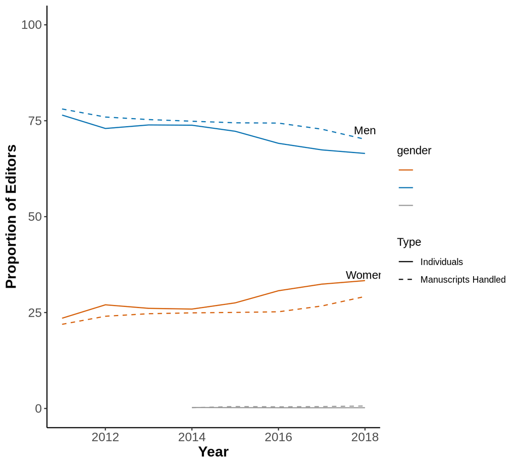

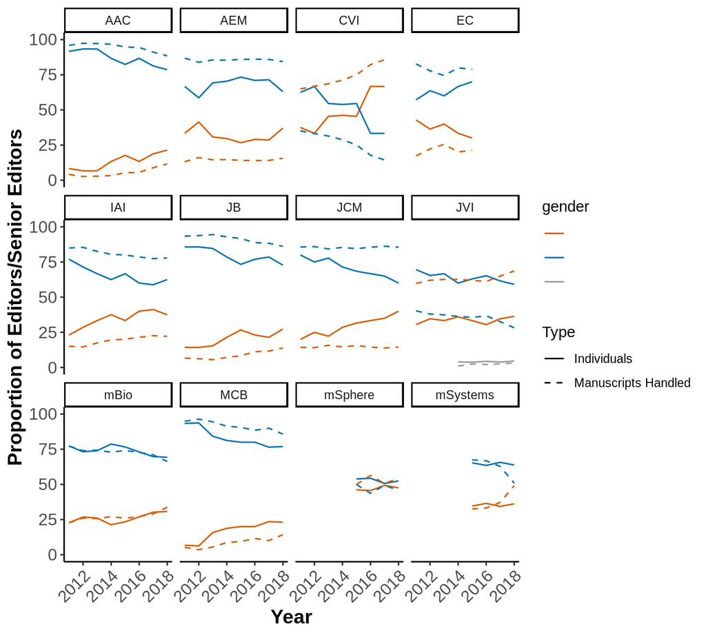

- Reviewer Notes:
  - Median number of paper reviews are equivalent across genders, though men seem slightly more likely to review more papers - trends representative of journals, except for MCB where “unclear” reviewers are a greater proportion than women
  - Slight increase in the proportion of women over time (& decrease of men), more women reviewers than “unclear”
  - trends and approximate proportions are equvalent for potential reviewers and actual reviewers
  - greater # of women (unique indvidiuals) have been suggested as potential reviewers than # of women senior authors – only 1/2 have actually been reviewers
  - similar trend for min, except that the proportions of potential & accepted seem to be higher - calculate & add proportions relative to senior authors
  - different trend for “unclear” authors where senior > potential > accepted
- Who carries the burden of peer review?
  - How often are reviewers participating on multiple manuscripts? – calculate proportion that only reviewed one paper
  - How does representation compare from potential to actual reviewer? – seems equivalent
  - Is it proportional to the author representation? – yes

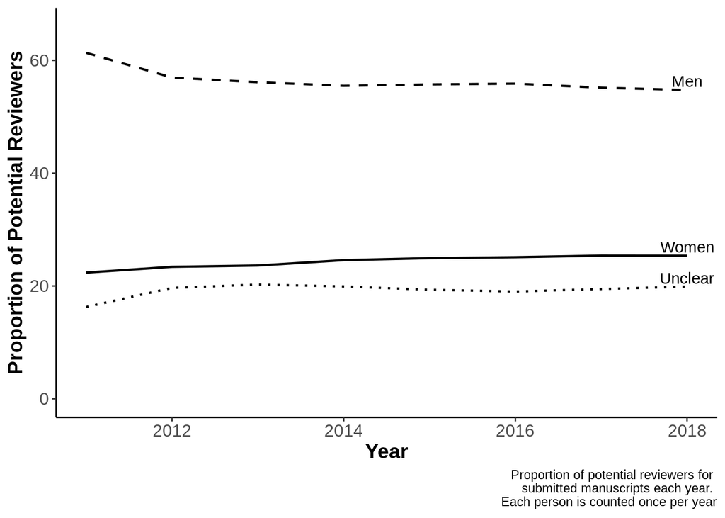

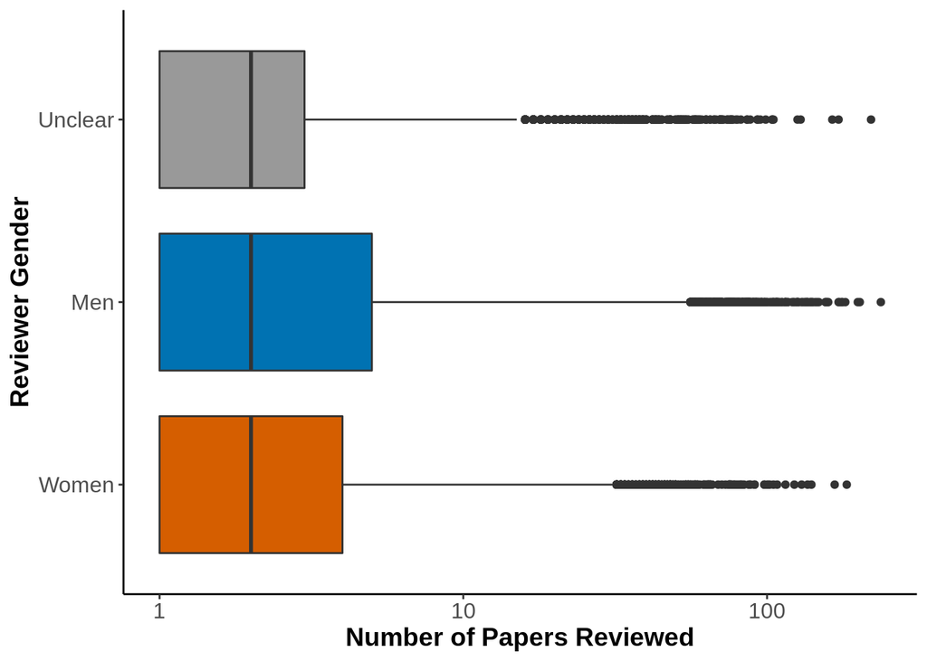

[figure not shown]

### Gender in Authorship

- Notes:
  - Proportions of men and women authors have decreased over time, while “unclear” has increased – gap between men & women proportions unchanged since 2012
  - ratio of women:men authors is 3:4
  - First & Middle author proportions are representative
  - Last & corresponding author proportions are representative
  - Women are first authors more often than other groups – decreasing trend of men/women first authors over time (increase of unclear)
  - Trends are similar across journals & genders
  - proportion of women corresponding/last authors has not increased over time
  - proportion of men senior authors has decreased over time – increase of unclear senior authors
  - proportion of published is higher for both men & women than submitted proportions – means that proportion of unclear published is lower than submitted
  - is the increase in published proportions, proportionally equivalent for men & women?
- How do the proportions compare by gender at each stage of peer review?
  - E.g., author, reviewer, editor, eic
  - Is there variation by journal?
  - Is it influenced by EiC gender?
  - How often are each gender on multiple submitted or published manuscripts?

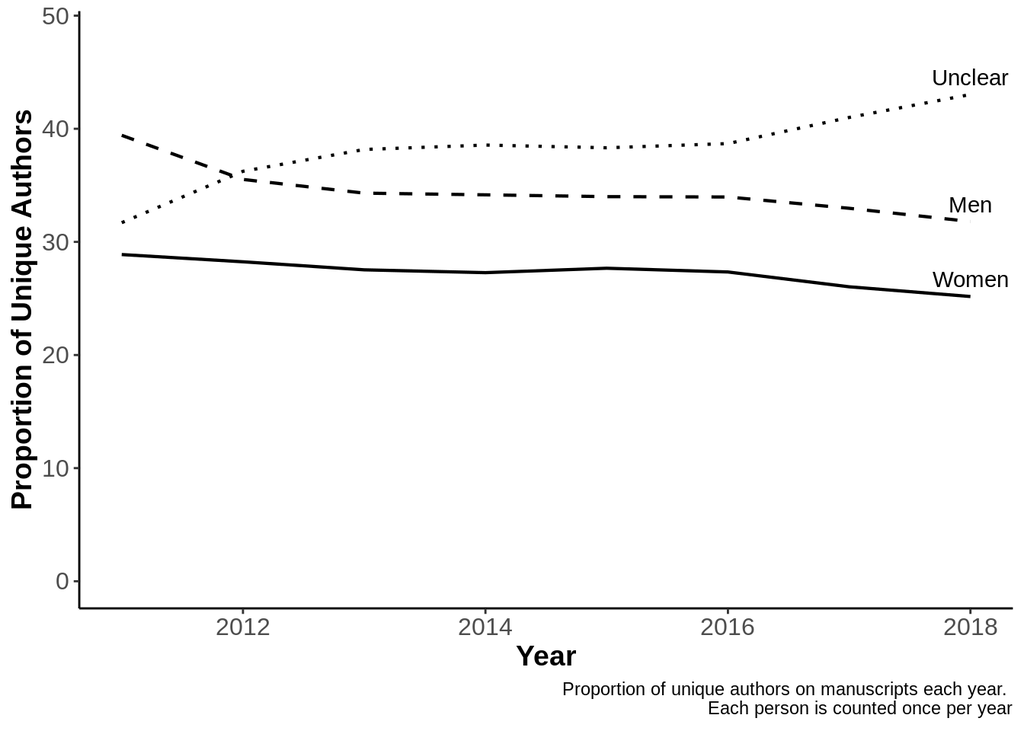

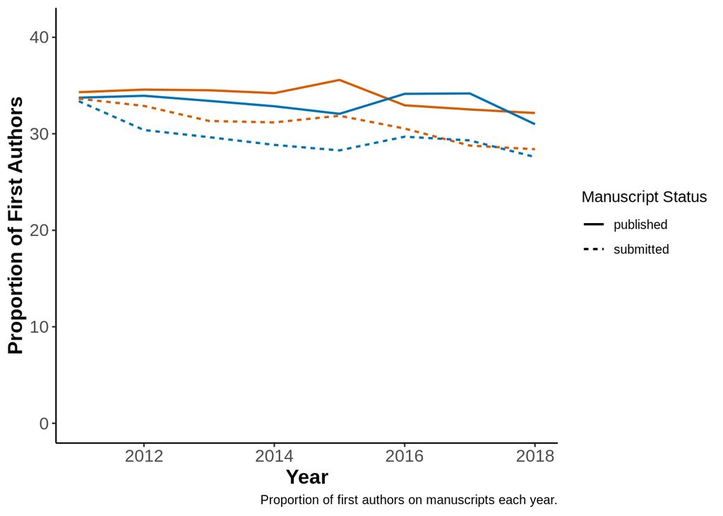

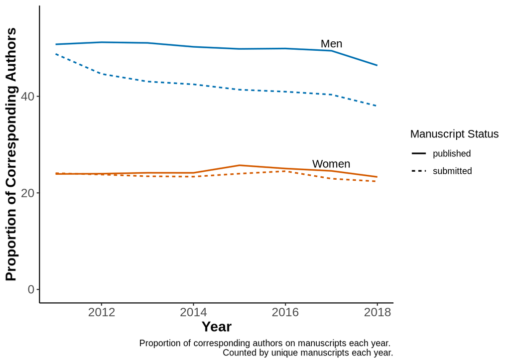

### Gender Summary

- How does gender representation of manuscripts compare from submitted to published?
  - proportion of M & W authored publications seems relatively disparate from M & W authored submissions – unknown if bias
  - “Publication Rate Disparity” = (M publish rate) - (W publish rate) – positive == men more likely to publish (i.e., overperform); negative == women more likely to publish
  - Men overperform in all authorship roles across ASM journals, most clear for corresponding authors
  - Break it down by journals and there is clear trend to overperformance by men in both corresponding & last authorships, some exceptions
- Are women being retained through peer review at the same proportion as men/unclear?
  - Get actual proportions at each stage
  - seems as if fewer women progress through each stage than men
  - large proportion of potential reviewers are not senior authors (both genders)

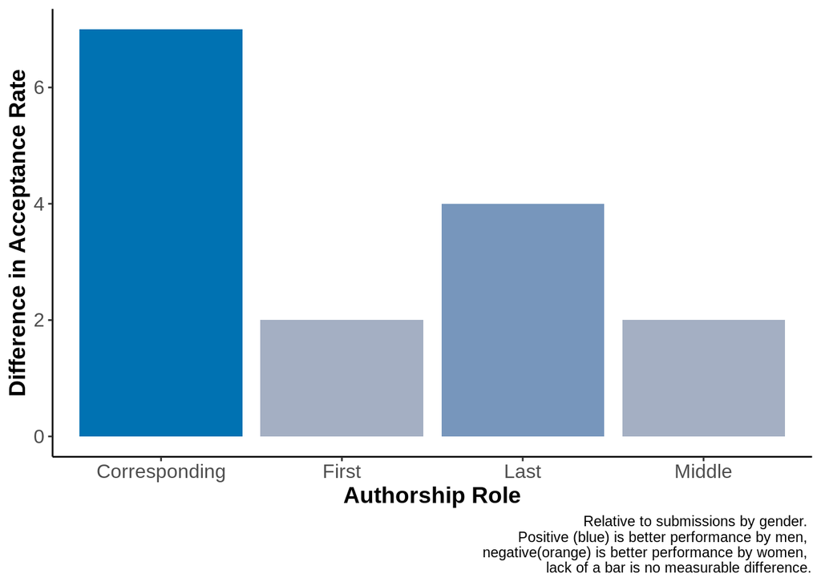

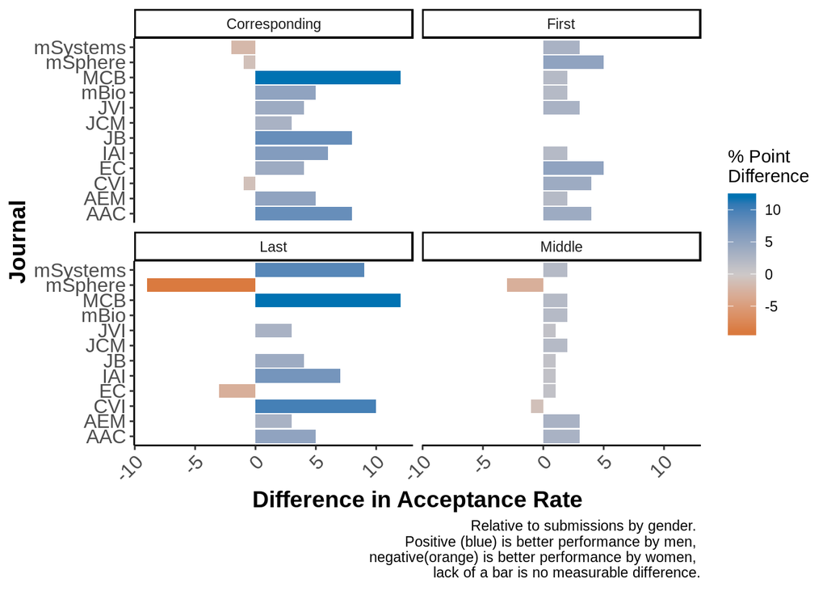

## Papers submitted by women are rejected more frequently than those submitted by men

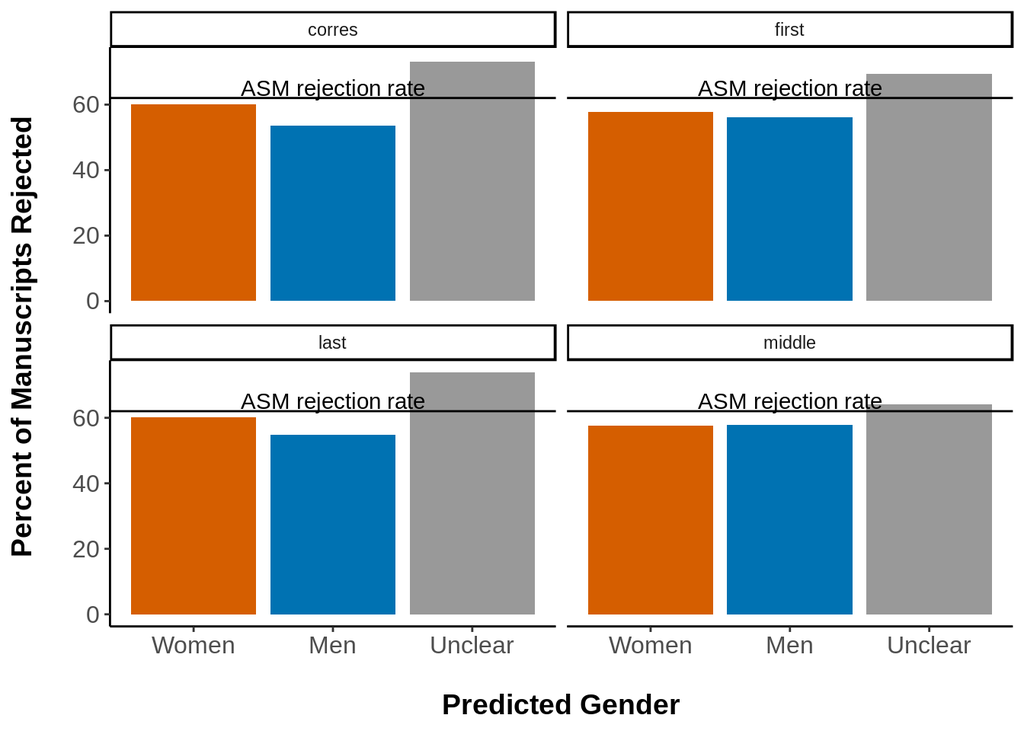

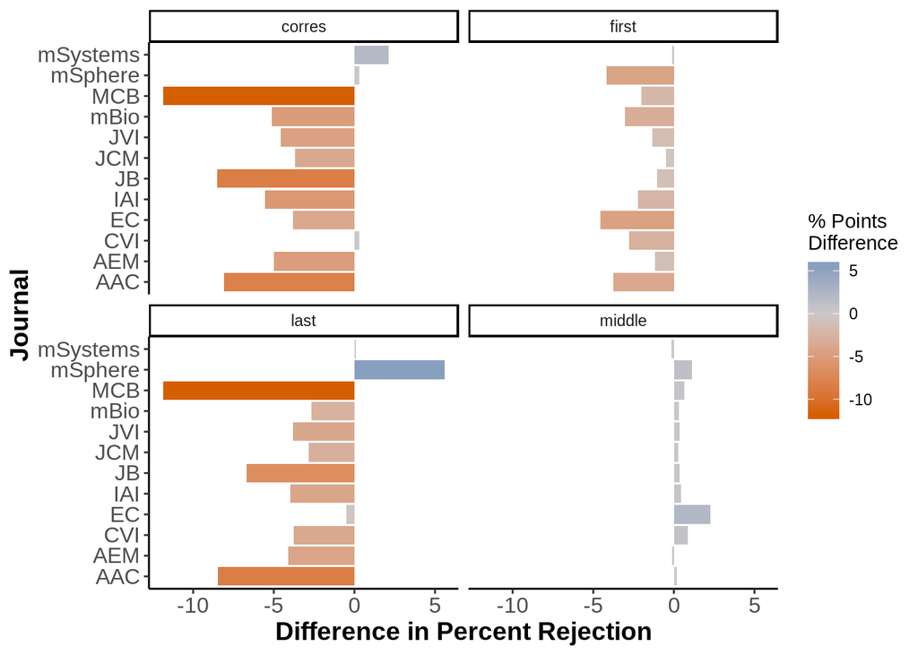

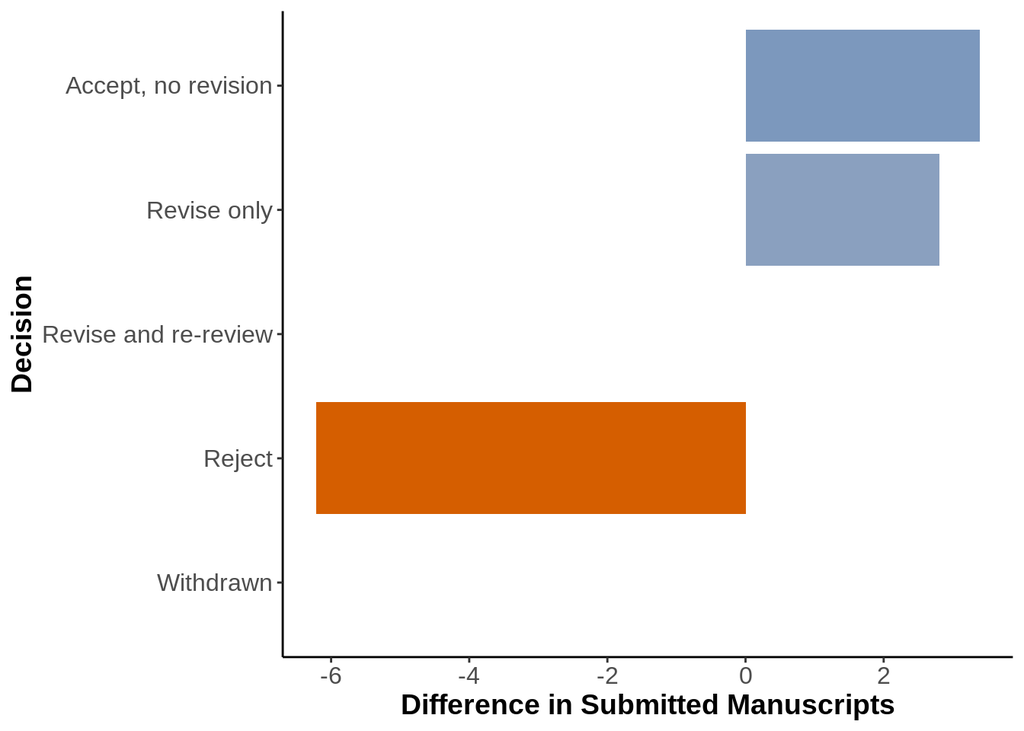

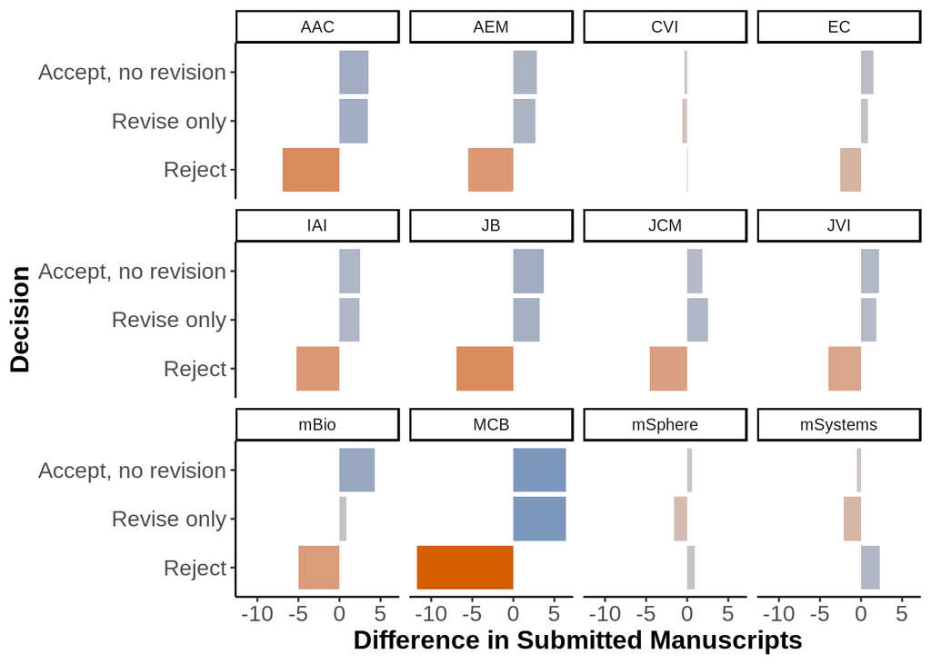

- NOTE: to correct for the large discrepency in the participation of women at ASM journals during the is time period, all comparisions are made relative to the gender and population in question.
- direct comparision of the proportion of woman-authored papers that are rejected compared to men, at each author stage
  - middle/first author rejected at similar rates
  - woman-authored (corres/last) rejected more frequently than men
  - there are several journals where the overall trend is repeated and/or amplified (e.g., AAC, IAI, JB, mBio, MCB)
  - greatest effect seen for corresponding authors, use this sub-population to further examine
- directly compare decisions made on submitted manuscripts by author gender
  - men recieve favorable decisions (accept, revise)
  - most decisions are Accept, Reject, Revise – look more closely at journal level
  - in most cases (except msphere, msystems, CVI), rejections are more frequently rendered to women than men